# Sprint 2 : S02 T05: Exploració de les dades

## Nivell I

### Exercici 1

#### Descarrega el data set Airlines Delay: Airline on-time statistics and delay causes i carrega’l a un pandas Dataframe.

#### Explora les dades que conté, i queda’t únicament amb les columnes que consideris rellevants.

```python
import pandas as pd
df= pd.read_csv(r"C:\users\hecto\OneDrive\Documentos\IT Data Science\Sprint2\Sprint2 Data Airline\DelayedFlights.csv",sep =",")
df.head(3)
```

|  | Unnamed: 0 | Year | Month | DayofMonth | DayOfWeek | DepTime | CRSDepTime | ArrTime | CRSArrTime | UniqueCarrier | ... | TaxiIn | TaxiOut | Cancelled | CancellationCode | Diverted | CarrierDelay | WeatherDelay | NASDelay | SecurityDelay | LateAircraftDelay |
| --- | --- | --- | --- | --- | --- | --- | --- | --- | --- | --- | --- | --- | --- | --- | --- | --- | --- | --- | --- | --- | --- |
| 0 | 0 | 2008 | 1 | 3 | 4 | 2003.0 | 1955 | 2211.0 | 2225 | WN | ... | 4.0 | 8.0 | 0 | N | 0 | NaN | NaN | NaN | NaN | NaN |
| 1 | 1 | 2008 | 1 | 3 | 4 | 754.0 | 735 | 1002.0 | 1000 | WN | ... | 5.0 | 10.0 | 0 | N | 0 | NaN | NaN | NaN | NaN | NaN |
| 2 | 2 | 2008 | 1 | 3 | 4 | 628.0 | 620 | 804.0 | 750 | WN | ... | 3.0 | 17.0 | 0 | N | 0 | NaN | NaN | NaN | NaN | NaN |

3 rows × 30 columns

""" El Data Frame contiene los siguientes campos de información:

1. Unnamed: id
2. Year: 2008
3. Month: 1-12
4. DayofMonth: 1-31
5. DayOfWeek: 1 (Monday) - 7 (Sunday)
6. DepTime: actual departure time (local, hhmm)
7. CRSDepTime: scheduled departure time (local, hhmm)
8. ArrTime: actual arrival time (local, hhmm)
9. CRSArrTime: scheduled arrival time (local, hhmm)
10. UniqueCarrier: unique carrier code
11. FlightNum: flight number
12. TailNum: plane tail number: aircraft registration, unique aircraft identifier
13. ActualElapsedTime: in minutes
14. CRSElapsedTime: in minutes
15. AirTime: in minutes
16. ArrDelay arrival delay, in minutes: A flight is counted as "on time" if it operated less than 15 minutes later the scheduled time shown in the carriers' Computerized Reservations Systems (CRS)
17. DepDelay: departure delay, in minutes
18. Origin: origin IATA airport code
19. Dest: destination IATA airport code
20. Distance: in miles
21. TaxiIn: taxi in time, in minutes
22. TaxiOut: taxi out time in minutes
23. Cancelled: *was the flight cancelled
24. CancellationCode: reason for cancellation (A = carrier, B = weather, C = NAS, D = security)
25. Diverted: 1 = yes, 0 = no
26. CarrierDelay: in minutes. Carrier delay is within the control of the air carrier. Examples of occurrences that may determine carrier delay are: aircraft cleaning, aircraft damage, awaiting the arrival of connecting passengers or crew, baggage, bird strike, cargo loading, catering, computer, outage-carrier equipment, crew legality (pilot or attendant rest), damage by hazardous goods, engineering inspection, fueling, handling disabled passengers, late crew, lavatory servicing, maintenance, oversales, potable water servicing, removal of unruly  
    passenger, slow boarding or seating, stowing carry-on baggage, weight and balance delays.
27. WeatherDelay: in minutes. Weather delay is caused by extreme or hazardous weather conditions that are forecasted or manifest themselves on point of departure, enroute, or on point of arrival.
28. NASDelay: in minutes. Delay that is within the control of the National Airspace System (NAS) may include: non-extreme weather conditions, airport operations, heavy traffic volume, air traffic control, etc.
29. SecurityDelay: in minutes. Security delay is caused by evacuation of a terminal or concourse, re-boarding of aircraft because of security  
    breach, inoperative screening equipment and/or long lines in excess of 29 minutes at screening areas.
30. LateAircraftDelay: in minutes. Arrival delay at an airport due to the late arrival of the same aircraft at a previous airport. The ripple effect of an earlier delay at downstream airports is referred to as delay propagation.

"""

```python
# descripcion estadistica las variables numéricas (int o float) y objectos
# quito la columna "Unname"
df.drop('Unnamed: 0',axis=1,inplace=True)
df.describe(include="all").round(1)
```

|  | Year | Month | DayofMonth | DayOfWeek | DepTime | CRSDepTime | ArrTime | CRSArrTime | UniqueCarrier | FlightNum | ... | TaxiIn | TaxiOut | Cancelled | CancellationCode | Diverted | CarrierDelay | WeatherDelay | NASDelay | SecurityDelay | LateAircraftDelay |
| --- | --- | --- | --- | --- | --- | --- | --- | --- | --- | --- | --- | --- | --- | --- | --- | --- | --- | --- | --- | --- | --- |
| count | 1936758.0 | 1936758.0 | 1936758.0 | 1936758.0 | 1936758.0 | 1936758.0 | 1929648.0 | 1936758.0 | 1936758 | 1936758.0 | ... | 1929648.0 | 1936303.0 | 1936758.0 | 1936758 | 1936758.0 | 1247488.0 | 1247488.0 | 1247488.0 | 1247488.0 | 1247488.0 |
| unique | NaN | NaN | NaN | NaN | NaN | NaN | NaN | NaN | 20 | NaN | ... | NaN | NaN | NaN | 4 | NaN | NaN | NaN | NaN | NaN | NaN |
| top | NaN | NaN | NaN | NaN | NaN | NaN | NaN | NaN | WN | NaN | ... | NaN | NaN | NaN | N | NaN | NaN | NaN | NaN | NaN | NaN |
| freq | NaN | NaN | NaN | NaN | NaN | NaN | NaN | NaN | 377602 | NaN | ... | NaN | NaN | NaN | 1936125 | NaN | NaN | NaN | NaN | NaN | NaN |
| mean | 2008.0 | 6.1 | 15.8 | 4.0 | 1518.5 | 1467.5 | 1610.1 | 1634.2 | NaN | 2184.3 | ... | 6.8 | 18.2 | 0.0 | NaN | 0.0 | 19.2 | 3.7 | 15.0 | 0.1 | 25.3 |
| std | 0.0 | 3.5 | 8.8 | 2.0 | 450.5 | 424.8 | 548.2 | 464.6 | NaN | 1944.7 | ... | 5.3 | 14.3 | 0.0 | NaN | 0.1 | 43.5 | 21.5 | 33.8 | 2.0 | 42.1 |
| min | 2008.0 | 1.0 | 1.0 | 1.0 | 1.0 | 0.0 | 1.0 | 0.0 | NaN | 1.0 | ... | 0.0 | 0.0 | 0.0 | NaN | 0.0 | 0.0 | 0.0 | 0.0 | 0.0 | 0.0 |
| 25% | 2008.0 | 3.0 | 8.0 | 2.0 | 1203.0 | 1135.0 | 1316.0 | 1325.0 | NaN | 610.0 | ... | 4.0 | 10.0 | 0.0 | NaN | 0.0 | 0.0 | 0.0 | 0.0 | 0.0 | 0.0 |
| 50% | 2008.0 | 6.0 | 16.0 | 4.0 | 1545.0 | 1510.0 | 1715.0 | 1705.0 | NaN | 1543.0 | ... | 6.0 | 14.0 | 0.0 | NaN | 0.0 | 2.0 | 0.0 | 2.0 | 0.0 | 8.0 |
| 75% | 2008.0 | 9.0 | 23.0 | 6.0 | 1900.0 | 1815.0 | 2030.0 | 2014.0 | NaN | 3422.0 | ... | 8.0 | 21.0 | 0.0 | NaN | 0.0 | 21.0 | 0.0 | 15.0 | 0.0 | 33.0 |
| max | 2008.0 | 12.0 | 31.0 | 7.0 | 2400.0 | 2359.0 | 2400.0 | 2400.0 | NaN | 9742.0 | ... | 240.0 | 422.0 | 1.0 | NaN | 1.0 | 2436.0 | 1352.0 | 1357.0 | 392.0 | 1316.0 |

11 rows × 29 columns

### Exercici 2

#### Fes un informe complet del data set:

#### 1. Resumeix estadísticament les columnes d'interès

##### 1.1 Matriz de correlaciones entre todas las variables del Data Frame

[figure not shown]

```python
import matplotlib.pyplot as plt
import numpy as np
from matplotlib.colors import LogNorm

# matriz de correlaciones
corrmat = df.corr()
#print(corrmat)

# dimensión de la tabla de colores definida a partir de una módulo aleatorio
Z = np.random.rand(30, 30)

#fig, ax0 = plt.subplots()
f, ax = plt.subplots(figsize=(12,9))
ax.pcolor(Z)

ax.set_title('Matriz de correlaciones')
#x,y = corrmat

#sns.heatmap(corrmat, vmax=10, square=True);
sns.heatmap(corrmat, cmap="YlGnBu", square = True)

plt.show()
```

""" Observaciones sobre los datos:

1. A través de la matriz de correlación se observa que algunas variables del conjunto de datos, presentan multicolinealidad, es decir, se pueden predecir linealmente a partir de otras.
2. Solo cuando el retraso en la llegada es superior a 15 minutos, se informa sobre la causa del retraso.
3. El retraso de llegada es: CarrierDelay + WeatherDelay + NASDelay + LateAircraftDelay.
4. En los casos de cancelación o desvío no hay datos relacionados con las causas del retraso.
5. La mayoría de ocasiones, los aeropuertos y los transportistas asignan un CRSElapsedTime superior al tiempo real empleado en las operaciones, Taxi In + Taxi out + Airtime (Tiempo transcurrido real). Por este motivo cuando los aviones despegan a tiempo, pueden aterrizar antes de la la hora prevista y les permite absorber retrasos por vuelos encadenados.

"""

##### 1.2 Minutos de retraso en la llegada del avión

```python
print(np.round(df['ArrDelay'].describe()))
```

```
count    1928371.0
mean          42.0
std           57.0
min         -109.0
25%            9.0
50%           24.0
75%           56.0
max         2461.0
Name: ArrDelay, dtype: float64
```

##### 1.3 Minutos de retraso en la salida del avión

```python
print(np.round(df['DepDelay'].describe()))
```

```
count    1936758.0
mean          43.0
std           53.0
min            6.0
25%           12.0
50%           24.0
75%           53.0
max         2467.0
Name: DepDelay, dtype: float64
```

##### 1.4 Graficos de Retrasos en las Salidas (en minutos) por Meses

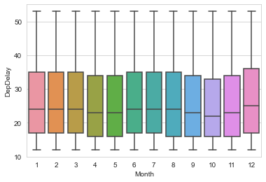

```python
# Se han eliminado los datos del quartile >0.75 porque desvirtuaban la escala del boxplot

df_no_outliers = df[df["DepDelay"].between(df["DepDelay"].quantile(.25), df["DepDelay"].quantile(.75))]
plot1= sns.boxplot(data=df_no_outliers.sort_values(by="DepDelay",ascending = False), x="Month", y="DepDelay")
plot1.figure.savefig("Dep_delay-Month_plot.png")
```

#### 2. Troba quantes dades faltants hi ha per columna

```python
#tipo de datos y cuántos nulos hay
df.info(show_counts = True)
```

[output not shown]

[output cut: 23 more lines]

```python
# dónde están los valores nulos
df.isnull().sum()
```

```
Year                      0
Month                     0
DayofMonth                0
DayOfWeek                 0
DepTime                   0
CRSDepTime                0
ArrTime                7110
CRSArrTime                0
UniqueCarrier             0
FlightNum                 0
TailNum                   5
ActualElapsedTime      8387
CRSElapsedTime          198
AirTime                8387
ArrDelay               8387
DepDelay                  0
Origin                    0
Dest                      0
Distance                  0
TaxiIn                 7110
TaxiOut                 455
Cancelled                 0
CancellationCode          0
Diverted                  0
CarrierDelay         689270
WeatherDelay         689270
NASDelay             689270
SecurityDelay        689270
LateAircraftDelay    689270
dtype: int64
```

```python
# porcentaje de valores nulos / total
(df.isnull().sum()/len(df)*100).round(1)
```

```
Year                  0.0
Month                 0.0
DayofMonth            0.0
DayOfWeek             0.0
DepTime               0.0
CRSDepTime            0.0
ArrTime               0.4
CRSArrTime            0.0
UniqueCarrier         0.0
FlightNum             0.0
TailNum               0.0
ActualElapsedTime     0.4
CRSElapsedTime        0.0
AirTime               0.4
ArrDelay              0.4
DepDelay              0.0
Origin                0.0
Dest                  0.0
Distance              0.0
TaxiIn                0.4
TaxiOut               0.0
Cancelled             0.0
CancellationCode      0.0
Diverted              0.0
CarrierDelay         35.6
WeatherDelay         35.6
NASDelay             35.6
SecurityDelay        35.6
LateAircraftDelay    35.6
dtype: float64
```

#### 3. Crea columnes noves (velocitat mitjana del vol, si ha arribat tard o no...)

##### 3.1 Columna de Velocidad Media del Vuelo

```python
# unidad de medida de la Velocidad Media (millas/horas)
df['Velocidad_Med']= df['Distance'].mean()*60/df['CRSElapsedTime'].mean()
df[:3]
```

|  | Year | Month | DayofMonth | DayOfWeek | DepTime | CRSDepTime | ArrTime | CRSArrTime | UniqueCarrier | FlightNum | ... | TaxiOut | Cancelled | CancellationCode | Diverted | CarrierDelay | WeatherDelay | NASDelay | SecurityDelay | LateAircraftDelay | Velocidad_Med |
| --- | --- | --- | --- | --- | --- | --- | --- | --- | --- | --- | --- | --- | --- | --- | --- | --- | --- | --- | --- | --- | --- |
| 0 | 2008 | 1 | 3 | 4 | 2003.0 | 1955 | 2211.0 | 2225 | WN | 335 | ... | 8.0 | 0 | N | 0 | NaN | NaN | NaN | NaN | NaN | 342.071712 |
| 1 | 2008 | 1 | 3 | 4 | 754.0 | 735 | 1002.0 | 1000 | WN | 3231 | ... | 10.0 | 0 | N | 0 | NaN | NaN | NaN | NaN | NaN | 342.071712 |
| 2 | 2008 | 1 | 3 | 4 | 628.0 | 620 | 804.0 | 750 | WN | 448 | ... | 17.0 | 0 | N | 0 | NaN | NaN | NaN | NaN | NaN | 342.071712 |

3 rows × 30 columns

##### 3.2 Columna de LLegada con Retraso o en Tiempo

```python
df['Llegada_retraso']=df.ArrDelay>=0
df[:5]
```

[output not shown]

5 rows × 32 columns

#### 4. Taula de les aerolínies amb més endarreriments acumulats

```python
df["TotalDelay"]=df['DepDelay']+df['ArrDelay']
df[:3]
```

[output not shown]

3 rows × 30 columns

```python
retraso = df[['UniqueCarrier','TotalDelay']].copy()
retraso_ok = retraso.dropna().sort_values("TotalDelay", ascending=False)
retraso_ok = retraso_ok.groupby('UniqueCarrier').aggregate(sum)
retraso_ok.sort_values("TotalDelay", ascending=False)
```

| UniqueCarrier | TotalDelay |
| --- | --- |
| WN | 24331347.0 |
| AA | 17746439.0 |
| UA | 13764664.0 |
| MQ | 12554319.0 |
| OO | 11869335.0 |
| XE | 10329576.0 |
| DL | 8971757.0 |
| CO | 8340506.0 |
| EV | 7834335.0 |
| YV | 7387293.0 |
| US | 7370623.0 |
| NW | 6715503.0 |
| FL | 6115528.0 |
| B6 | 6043070.0 |
| OH | 5241678.0 |
| 9E | 4862296.0 |
| AS | 2888170.0 |
| F9 | 1569572.0 |
| HA | 502618.0 |
| AQ | 35176.0 |

##### 4.2 Grafico de los Retrasos en las Salidas por Compañías Aéreas

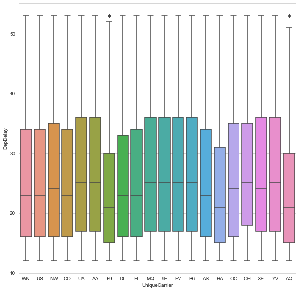

```python
df_no_outliers = df[df["DepDelay"].between(df["DepDelay"].quantile(.25), df["DepDelay"].quantile(.75))]
plt.figure(figsize=(10,10))
plot1= sns.boxplot(data=df_no_outliers.sort_values(by="DepDelay",ascending=True), x="UniqueCarrier", y="DepDelay")
plot1.figure.savefig("Dep_delay_UniqueCarrier_plot.png")
```

###### Las aerolínias con menores retrasos son: F9, HA y AQ

##### 4.3 Grafico de los Retrasos en las Llegadas por Compañías Aéreas

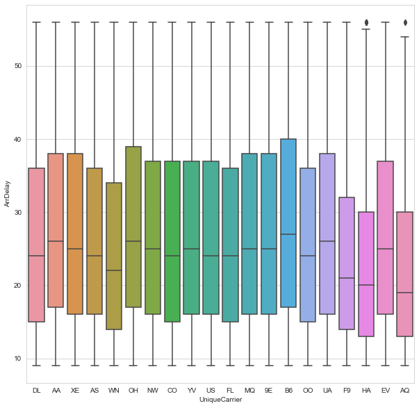

```python
df_no_outliers = df[df["ArrDelay"].between(df["ArrDelay"].quantile(.25), df["ArrDelay"].quantile(.75))]
plt.figure(figsize=(10,10))
plot1= sns.boxplot(data=df_no_outliers.sort_values(by="ArrDelay",ascending=True), x="UniqueCarrier", y="ArrDelay")
plot1.figure.savefig("Arr_delay_UniqueCarrier_plot.png")
```

###### Las aerolíneas con menores retrasos en las llegadas son: HA, AQ y F9

#### 5. Quins són els vols més llargs? I els més endarrerits?

##### 5.1 Más tiempo en Aire

```python
# Creamos un Data Frame para clasificar los códigos de los vuelos en un mismo campo Compañía/Número de Vuelo
df["FlightCode"] = df["UniqueCarrier"].astype(str) + "/" + df["FlightNum"].astype(str)
vuelosLargos = pd.DataFrame(df, columns=["AirTime","FlightCode"]).copy()
vuelosLargos_ok = vuelosLargos.dropna()
vuelosLargos_ok[:5]
```

|  | AirTime | FlightCode |
| --- | --- | --- |
| 0 | 116.0 | WN/335 |
| 1 | 113.0 | WN/3231 |
| 2 | 76.0 | WN/448 |
| 3 | 77.0 | WN/3920 |
| 4 | 87.0 | WN/378 |

```python
##### Ordenamos de forma ascendente los Vuelos más Largos en función de "AirTime"
vuelosLargos_ok.sort_values("AirTime", ascending=False).head()
```

|  | AirTime | FlightCode |
| --- | --- | --- |
| 1488690 | 1091.0 | HA/21 |
| 1367047 | 733.0 | HA/28 |
| 362529 | 664.0 | CO/15 |
| 556381 | 655.0 | CO/15 |
| 556385 | 654.0 | CO/15 |

##### 5.2 Vuelos más Largos

```python
df["FlightCode"] = df["UniqueCarrier"].astype(str) + "/" + df["FlightNum"].astype(str)
vuelosLargos = pd.DataFrame(df, columns=["ActualElapsedTime","FlightCode"]).copy()
vuelosLargos_ok = vuelosLargos.dropna()
vuelosLargos_ok[:5]
```

|  | ActualElapsedTime | FlightCode |
| --- | --- | --- |
| 0 | 128.0 | WN/335 |
| 1 | 128.0 | WN/3231 |
| 2 | 96.0 | WN/448 |
| 3 | 90.0 | WN/3920 |
| 4 | 101.0 | WN/378 |

```python
vuelosLargos_ok.sort_values("ActualElapsedTime", ascending=False).head()
```

|  | ActualElapsedTime | FlightCode |
| --- | --- | --- |
| 1488690 | 1114.0 | HA/21 |
| 1926817 | 790.0 | CO/15 |
| 1173580 | 776.0 | DL/151 |
| 1418032 | 750.0 | CO/15 |
| 1367047 | 750.0 | HA/28 |

##### 5.3 Vuelos más retrasados

```python
retrasados = pd.DataFrame(df, columns=["ArrDelay","FlightCode"]).copy()
retrasados_ok = Retrasados.dropna()
retrasados_ok.sort_values('ArrDelay', ascending=False).head()
```

[output not shown]

##### 5.4 Los 5 aeropuertos con más retraso en la salida

```python
airDelays = df[["DepDelay","Origin"]].copy()
airportDelays = airDelays.groupby("Origin").aggregate(sum)
airportDelays.sort_values("DepDelay", ascending=False)[:5]
```

| Origin | DepDelay |
| --- | --- |
| ORD | 6365866.0 |
| ATL | 5382082.0 |
| DFW | 3658231.0 |
| DEN | 2801893.0 |
| EWR | 2669013.0 |

### Exercici 3

#### Exporta el data set net i amb les noves columnes a Excel.

```python
path = "C:\\Users\hecto\\Downloads\\DelayedFlightsVams.csv"
df.to_csv(path, index = False)
```

```python
df.info(show_counts = True)
```

```
<class 'pandas.core.frame.DataFrame'>
RangeIndex: 1936758 entries, 0 to 1936757
Data columns (total 31 columns):
 #   Column             Non-Null Count    Dtype
---  ------             --------------    -----
 0   Year               1936758 non-null  int64
 1   Month              1936758 non-null  int64
 2   DayofMonth         1936758 non-null  int64
 3   DayOfWeek          1936758 non-null  int64
 4   DepTime            1936758 non-null  float64
 5   CRSDepTime         1936758 non-null  int64
 6   ArrTime            1929648 non-null  float64
 7   CRSArrTime         1936758 non-null  int64
 8   UniqueCarrier      1936758 non-null  object
 9   FlightNum          1936758 non-null  int64
```

[output cut: 23 more lines]